# GO Analysis

Group 1

2023-06-20

#packages:

```r
suppressPackageStartupMessages({
  library(GenomicRanges)
  library(BiocGenerics)
  library(epiwraps)
  library(ggplot2)
  library(ggforce)
  library(rGREAT)
  library(AnnotationHub)
  library(Rsamtools)
  library(cowplot)
  library(GenomicRanges)
  library(ChIPseeker)
  library(ggplot2)
  library(dplyr)
  library(reshape2)
  library(utils)
})
```

In the paper, initially, a GO (Gene Ontology) pathway analysis was conducted on all RNA-expressing genes. The Gene Ontology “biological process” database serves as vocabulary for the dynamic roles of genes or gene products in cells. The vocabulary ranges from higher level, more broad terms such as ‘cell growth and maintenance’ down to very specific denominations (Ashburner et al., 2000).

GR RNA, in the original paper, wasn’t alone significantly associated with any gene pathway: Instead, MR RNA was associated with genes involved in cilium structure and function. Genes that were associated with both MR and GR, were involved in the post-synapse structure and neuronal as well as dendritic spine morphology and function.

In Addition to the GO analysis the Ingenuity Pathway Analysis suite (IPA) was used in the paper to analyze both FS30 and BLPM in the MR and GR ChIP-Seq data. The IPA confirmed the association of MR and cilia-related structures and dysfunctions. Additionally, the IPA analysis showed that there are several genes involved in cell morphology, cell-to-cell signaling, cell development (functional pathway formation, neuronal development, and migratory pathways), and synaptic transmission (including long–term potentiation (LTP) and long–term depression (LTD)).

Initially, we wanted to implement a GO Pathways analysis with an online GREAT (genomic Regions Enrichment of Annotations Tool) analysis. However, the rat genome (Rn6) isn’t supported with this version (supported genomes are: “hg38”, “hg19”, “mm10” and “mm9”). Instead, we opted to do a GO analysis with rGREAT locally. This version enables the selection of the specific genome, within the TxDb.* packages (Team BC & Maintainer BP, 2019), which provide the data for Gene Ontology gene sets. The data source might cause some differences, as the transcription start sites (TSS) can be inconsistent between the various annotations. However, as noted by Gu & Hübschmann (2023) the differences in TSS annotations have little effect on the enrichment results.

In the first part of the analysis, we ran the GO analysis on the individual conditions (MR and GR at BLAM, FS30 and BLPM). In the second part the GO analysis was run on the individual clusters.

```r
#import BLAM GR peaks
peakfiles <- list.files("/Users/janmatthias/Documents/GitHub/bioinformatics_final_project/Jan /NarrowPeaks", pattern = "Early_morning_baseline_GR_peaks.narrowPeak", full.name=TRUE)
peaks_BLAM_GR <- lapply(peakfiles, FUN=rtracklayer::import)
#peaks_BLAM_GR <- lapply(peaks_BLAM_GR, FUN=function(x) x[x$score>800])
peaks_BLAM_GR <- reduce(unlist(GRangesList(peaks_BLAM_GR)))

result_BLAM_GR <-great(peaks_BLAM_GR, "GO:BP", biomart_dataset = "rnorvegicus_gene_ensembl")
```

```
## * get gene and GO genesets from biomart (dataset: rnorvegicus_gene_ensembl).
```

```
## * background chromosomes from BioMart are '1, 2, 3, 4, 5, 6, 7, 8, 9, 10, 11, 12, 13, 14,
##     15, 16, 17, 18, 19, 20, X, Y, M'.
```

```
## * TSS extension mode is 'basalPlusExt'.
```

```
## * construct the basal domains by extending 5000bp to upstream and 1000bp to downsteram of TSS.
```

```
## * calculate distances to neighbour regions.
```

```
## * extend to both sides until reaching the neighbour genes or to the maximal extension.
```

```
## * check gene ID type in `gene_sets` and in `extended_tss`.
```

```
## * use whole genome as background.
```

```
## * remove excluded regions from background.
```

```
## * overlap `gr` to background regions (based on midpoint).
```

```
## * in total 616 `gr`.
```

```
## * overlap extended TSS to background regions.
```

```
## * check which genes are in the gene sets.
```

```
## * only take gene sets with size >= 5.
```

```
## * in total 9103 gene sets.
```

```
## * overlap `gr` to every extended TSS.
```

```
## * perform binomial test for each biological term.
```

```r
result_BLAM_GR <- rGREAT::getEnrichmentTables(result_BLAM_GR)

#import FS30 GR peaks
peakfiles <- list.files("/Users/janmatthias/Documents/GitHub/bioinformatics_final_project/Jan /NarrowPeaks", pattern = "Acute_stress_GR_peaks.narrowPeak", full.name=TRUE)
peaks_FS30_GR <- lapply(peakfiles, FUN=rtracklayer::import)
#peaks_FS30_GR <- lapply(peaks_FS30_GR, FUN=function(x) x[x$score>800])
peaks_FS30_GR <- reduce(unlist(GRangesList(peaks_FS30_GR)))

result_FS30_GR <-great(peaks_FS30_GR, "GO:BP", biomart_dataset = "rnorvegicus_gene_ensembl")
```

```
## * get gene and GO genesets from biomart (dataset: rnorvegicus_gene_ensembl).
```

```
## * background chromosomes from BioMart are '1, 2, 3, 4, 5, 6, 7, 8, 9, 10, 11, 12, 13, 14,
##     15, 16, 17, 18, 19, 20, X, Y, M'.
```

```
## * TSS extension mode is 'basalPlusExt'.
```

```
## * construct the basal domains by extending 5000bp to upstream and 1000bp to downsteram of TSS.
```

```
## * calculate distances to neighbour regions.
```

```
## * extend to both sides until reaching the neighbour genes or to the maximal extension.
```

```
## * check gene ID type in `gene_sets` and in `extended_tss`.
```

```
## * use whole genome as background.
```

```
## * remove excluded regions from background.
```

```
## * overlap `gr` to background regions (based on midpoint).
```

```
## * in total 5882 `gr`.
```

```
## * overlap extended TSS to background regions.
```

```
## * check which genes are in the gene sets.
```

```
## * only take gene sets with size >= 5.
```

```
## * in total 9103 gene sets.
```

```
## * overlap `gr` to every extended TSS.
```

```
## * perform binomial test for each biological term.
```

```r
result_FS30_GR <- rGREAT::getEnrichmentTables(result_FS30_GR)

# import BLPM GR peaks
peakfiles <- list.files("/Users/janmatthias/Documents/GitHub/bioinformatics_final_project/Jan /NarrowPeaks", pattern = "Late_afternoon_baseline_GR_peaks.narrowPeak", full.name=TRUE)
peaks_BLPM_GR <- lapply(peakfiles, FUN=rtracklayer::import)
#peaks_BLPM_GR <- lapply(peaks_BLPM_GR, FUN=function(x) x[x$score>800])
peaks_BLPM_GR <- reduce(unlist(GRangesList(peaks_BLPM_GR)))

result_BLPM_GR <-great(peaks_BLPM_GR, "GO:BP", biomart_dataset = "rnorvegicus_gene_ensembl")
```

```
## * get gene and GO genesets from biomart (dataset: rnorvegicus_gene_ensembl).
```

```
## * background chromosomes from BioMart are '1, 2, 3, 4, 5, 6, 7, 8, 9, 10, 11, 12, 13, 14,
##     15, 16, 17, 18, 19, 20, X, Y, M'.
```

```
## * TSS extension mode is 'basalPlusExt'.
```

```
## * construct the basal domains by extending 5000bp to upstream and 1000bp to downsteram of TSS.
```

```
## * calculate distances to neighbour regions.
```

```
## * extend to both sides until reaching the neighbour genes or to the maximal extension.
```

```
## * check gene ID type in `gene_sets` and in `extended_tss`.
```

```
## * use whole genome as background.
```

```
## * remove excluded regions from background.
```

```
## * overlap `gr` to background regions (based on midpoint).
```

```
## * in total 5251 `gr`.
```

```
## * overlap extended TSS to background regions.
```

```
## * check which genes are in the gene sets.
```

```
## * only take gene sets with size >= 5.
```

```
## * in total 9103 gene sets.
```

```
## * overlap `gr` to every extended TSS.
```

```
## * perform binomial test for each biological term.
```

```r
result_BLPM_GR <- rGREAT::getEnrichmentTables(result_BLPM_GR)

#import BLAM MR peaks
peakfiles <- list.files("/Users/janmatthias/Documents/GitHub/bioinformatics_final_project/Jan /NarrowPeaks", pattern = "Early_morning_baseline_MR_peaks.narrowPeak", full.name=TRUE)
peaks_BLAM_MR <- lapply(peakfiles, FUN=rtracklayer::import)
#peaks_BLAM_MR <- lapply(peaks_BLAM_MR, FUN=function(x) x[x$score>800])
peaks_BLAM_MR <- reduce(unlist(GRangesList(peaks_BLAM_MR)))

result_BLAM_MR <-great(peaks_BLAM_MR, "GO:BP", biomart_dataset = "rnorvegicus_gene_ensembl")
```

```
## * get gene and GO genesets from biomart (dataset: rnorvegicus_gene_ensembl).
```

```
## * background chromosomes from BioMart are '1, 2, 3, 4, 5, 6, 7, 8, 9, 10, 11, 12, 13, 14,
##     15, 16, 17, 18, 19, 20, X, Y, M'.
```

```
## * TSS extension mode is 'basalPlusExt'.
```

```
## * construct the basal domains by extending 5000bp to upstream and 1000bp to downsteram of TSS.
```

```
## * calculate distances to neighbour regions.
```

```
## * extend to both sides until reaching the neighbour genes or to the maximal extension.
```

```
## * check gene ID type in `gene_sets` and in `extended_tss`.
```

```
## * use whole genome as background.
```

```
## * remove excluded regions from background.
```

```
## * overlap `gr` to background regions (based on midpoint).
```

```
## * in total 627 `gr`.
```

```
## * overlap extended TSS to background regions.
```

```
## * check which genes are in the gene sets.
```

```
## * only take gene sets with size >= 5.
```

```
## * in total 9103 gene sets.
```

```
## * overlap `gr` to every extended TSS.
```

```
## * perform binomial test for each biological term.
```

```r
result_BLAM_MR <- rGREAT::getEnrichmentTables(result_BLAM_MR)

#import FS30 MR peaks
peakfiles <- list.files("/Users/janmatthias/Documents/GitHub/bioinformatics_final_project/Jan /NarrowPeaks", pattern = "Acute_stress_MR_peaks.narrowPeak", full.name=TRUE)
peaks_FS30_MR <- lapply(peakfiles, FUN=rtracklayer::import)
#peaks_FS30_MR <- lapply(peaks_FS30_MR, FUN=function(x) x[x$score>800])
peaks_FS30_MR <- reduce(unlist(GRangesList(peaks_FS30_MR)))

result_FS30_MR <-great(peaks_FS30_MR, "GO:BP", biomart_dataset = "rnorvegicus_gene_ensembl")
```

```
## * get gene and GO genesets from biomart (dataset: rnorvegicus_gene_ensembl).
```

```
## * background chromosomes from BioMart are '1, 2, 3, 4, 5, 6, 7, 8, 9, 10, 11, 12, 13, 14,
##     15, 16, 17, 18, 19, 20, X, Y, M'.
```

```
## * TSS extension mode is 'basalPlusExt'.
```

```
## * construct the basal domains by extending 5000bp to upstream and 1000bp to downsteram of TSS.
```

```
## * calculate distances to neighbour regions.
```

```
## * extend to both sides until reaching the neighbour genes or to the maximal extension.
```

```
## * check gene ID type in `gene_sets` and in `extended_tss`.
```

```
## * use whole genome as background.
```

```
## * remove excluded regions from background.
```

```
## * overlap `gr` to background regions (based on midpoint).
```

```
## * in total 6783 `gr`.
```

```
## * overlap extended TSS to background regions.
```

```
## * check which genes are in the gene sets.
```

```
## * only take gene sets with size >= 5.
```

```
## * in total 9103 gene sets.
```

```
## * overlap `gr` to every extended TSS.
```

```
## * perform binomial test for each biological term.
```

```r
result_FS30_MR <- rGREAT::getEnrichmentTables(result_FS30_MR)

# import BLPM GR peaks
peakfiles <- list.files("/Users/janmatthias/Documents/GitHub/bioinformatics_final_project/Jan /NarrowPeaks", pattern = "Late_afternoon_baseline_MR_peaks.narrowPeak", full.name=TRUE)
peaks_BLPM_MR <- lapply(peakfiles, FUN=rtracklayer::import)
#peaks_BLPM_MR <- lapply(peaks_BLPM_MR, FUN=function(x) x[x$score>800])
peaks_BLPM_MR <- reduce(unlist(GRangesList(peaks_BLPM_MR)))

result_BLPM_MR <-great(peaks_BLPM_MR, "GO:BP", biomart_dataset = "rnorvegicus_gene_ensembl")
```

```
## * get gene and GO genesets from biomart (dataset: rnorvegicus_gene_ensembl).
```

```
## * background chromosomes from BioMart are '1, 2, 3, 4, 5, 6, 7, 8, 9, 10, 11, 12, 13, 14,
##     15, 16, 17, 18, 19, 20, X, Y, M'.
```

```
## * TSS extension mode is 'basalPlusExt'.
```

```
## * construct the basal domains by extending 5000bp to upstream and 1000bp to downsteram of TSS.
```

```
## * calculate distances to neighbour regions.
```

```
## * extend to both sides until reaching the neighbour genes or to the maximal extension.
```

```
## * check gene ID type in `gene_sets` and in `extended_tss`.
```

```
## * use whole genome as background.
```

```
## * remove excluded regions from background.
```

```
## * overlap `gr` to background regions (based on midpoint).
```

```
## * in total 7648 `gr`.
```

```
## * overlap extended TSS to background regions.
```

```
## * check which genes are in the gene sets.
```

```
## * only take gene sets with size >= 5.
```

```
## * in total 9103 gene sets.
```

```
## * overlap `gr` to every extended TSS.
```

```
## * perform binomial test for each biological term.
```

```r
result_BLPM_MR <- rGREAT::getEnrichmentTables(result_BLPM_MR)

a<- ggplot(head(result_BLAM_MR,10), aes(fold_enrichment_hyper, reorder(breakStrings(description, 10, "\n"), p_adjust_hyper), size=fold_enrichment, color=-log10(p_adjust_hyper))) + scale_color_viridis_c() + geom_point()+ labs(title = "Biological Processes BLAM MR", x = "Hyper Fold Enrichment", y = "Name of the Biological Process", colour = "Minus Logarithm of the \nAdjusted Hypergeometric p-Values \n(-log10(Hyper_Adjp_BH))", size = "Hyper Foreground Region Hits") + theme(plot.title = element_text(hjust = 0.5))

b<- ggplot(head(result_FS30_MR,10), aes(fold_enrichment_hyper, reorder(breakStrings(description, 10, "\n"), p_adjust_hyper), size=fold_enrichment, color=-log10(p_adjust_hyper))) + scale_color_viridis_c()+ geom_point() + labs(title = "Biological Processes FS30 MR ", x = "Hyper Fold Enrichment", y = "Name of the Biological Process", colour = "Minus Logarithm of the \nAdjusted Hypergeometric p-Values \n(-log10(Hyper_Adjp_BH))", size = "Hyper Foreground Region Hits") + theme(plot.title = element_text(hjust = 0.5))


c<-ggplot(head(result_BLPM_MR,10), aes(fold_enrichment_hyper, reorder(breakStrings(description, 10, "\n"), p_adjust_hyper), size=fold_enrichment, color=-log10(p_adjust_hyper))) + scale_color_viridis_c()+ geom_point()  + labs(title = "Biological Processes BLPM MR", x = "Hyper Fold Enrichment", y = "Name of the Biological Process", colour = "Minus Logarithm of the \nAdjusted Hypergeometric p-Values \n(-log10(Hyper_Adjp_BH))", size = "Hyper Foreground Region Hits") + theme(plot.title = element_text(hjust = 0.5))

d<- ggplot(head(result_BLAM_GR,10), aes(fold_enrichment_hyper, reorder(breakStrings(description, 10, "\n"), p_adjust_hyper), size=fold_enrichment, color=-log10(p_adjust_hyper)))+ scale_color_viridis_c() + geom_point() + labs(title = "Biological Processes BLAM GR", x = "Hyper Fold Enrichment", y = "Name of the Biological Process", colour = "Minus Logarithm of the \nAdjusted Hypergeometric p-Values \n(-log10(Hyper_Adjp_BH))", size = "Hyper Foreground Region Hits") + theme(plot.title = element_text(hjust = 0.5))

e<- ggplot(head(result_FS30_GR,10), aes(fold_enrichment_hyper, reorder(breakStrings(description, 10, "\n"), p_adjust_hyper), size=fold_enrichment, color=-log10(p_adjust_hyper))) + scale_color_viridis_c()+ geom_point()+ labs(title = "Biological Processes FS30 GR ", x = "Hyper Fold Enrichment", y = "Name of the Biological Process", colour = "Minus Logarithm of the \nAdjusted Hypergeometric p-Values \n(-log10(Hyper_Adjp_BH))", size = "Hyper Foreground Region Hits") + theme(plot.title = element_text(hjust = 0.5))


f<-ggplot(head(result_BLPM_GR,10), aes(fold_enrichment_hyper, reorder(breakStrings(description, 10, "\n"), p_adjust_hyper), size=fold_enrichment, color=-log10(p_adjust_hyper))) + scale_color_viridis_c()+ geom_point() + labs(title = "Biological Processes BLPM GR", x = "Hyper Fold Enrichment", y = "Name of the Biological Process", colour = "Minus Logarithm of the \nAdjusted Hypergeometric p-Values \n(-log10(Hyper_Adjp_BH))", size = "Hyper Foreground Region Hits") + theme(plot.title = element_text(hjust = 0.5))
```

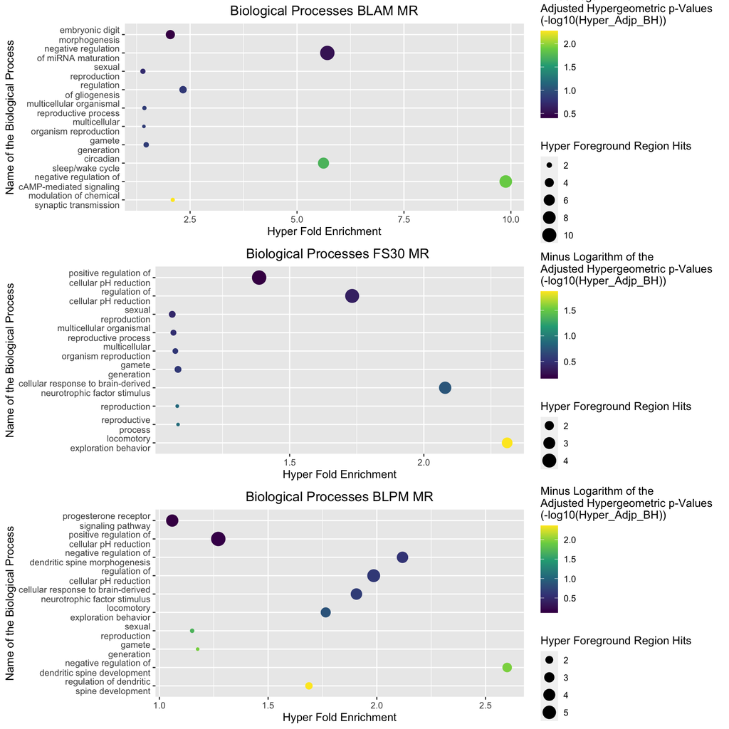

```r
plot_grid(a, b, c, ncol = 1)
```

In the MR analysis in the BLAM state negative regulation of miRNA, circadian sleep-wake cycle, and negative regulation of cAMP-mediated signaling are up-regulated. When the rats are under the stressed condition (FS30), there is an up-regulation of genes associated with the cellular response to brain-derived neurotrophic factor stimulus, locomotory exploration behavior, and regulation of cellular pH. Instead in the BLPM condition, there is an up-regulation of pathways associated with negative regulation of dendritic spine development and morphogenesis.

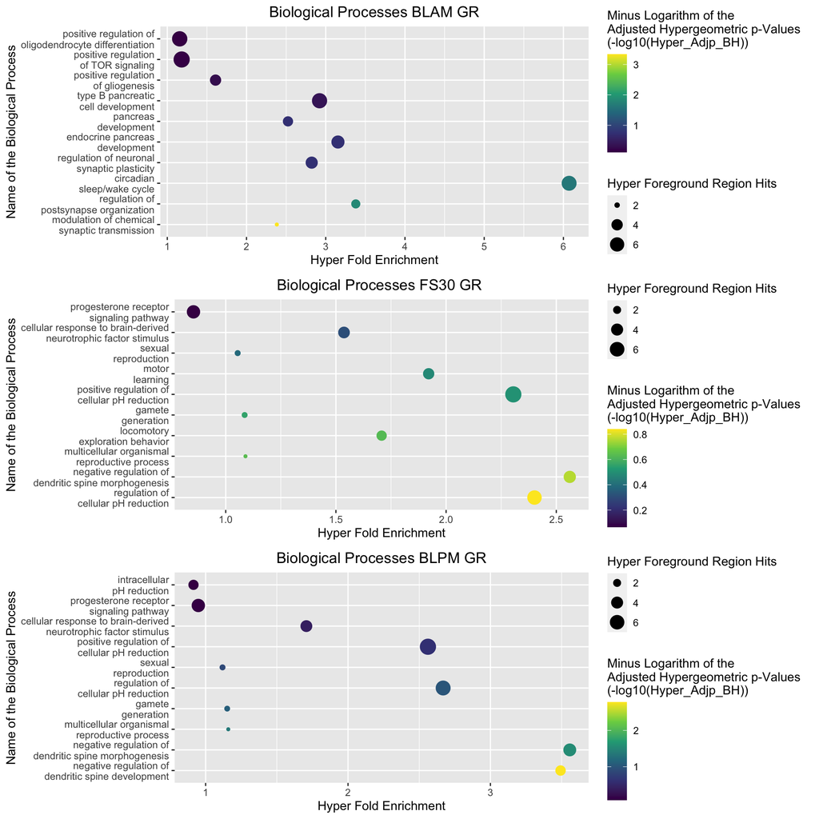

```r
plot_grid(d, e, f, ncol = 1)
```

In the GR analysis in the BLAM, there is a high prevalence of pathways associated with the circadian sleep/wake cycle. There are also other functions involved such as regularization of post synapse organization and type B pancreatic cell development. In the FS30 condition, there is an upregulation of negative regulation of the dendritic spine morphogenesis, positive regulation of cellular pH reduction, and regulation of cellular pH. In the BLPM negative regulation of dendritic spine morphogenesis/development are upregulated. There is also an upregulation of positive regulation of cellular pH reduction.